# Tutorial: bulk RNA-seq deconvolution using BayesPrism

Tinyi Chu

Note: if you use BayesPrism in published research, please cite:

> Chu, T., Wang, Z., Pe’er, D. Danko, C. G. Cell type and gene expression deconvolution with BayesPrism enables Bayesian integrative analysis across bulk and single-cell RNA sequencing in oncology. Nat Cancer 3, 505–517 (2022). https://doi.org/10.1038/s43018-022-00356-3

# Introduction

BayesPrism performs cell type and gene expression deconvolution for bulk RNA-seq (and spatial transcriptomics) using scRNA-seq of samples collected from matched or similar tissue type. It treats the scRNA-seq as prior information, and estimates $\mathrm{P}(\theta, Z | X, \phi)$ , i.e. the joint posterior distribution of cell type fraction $\theta$ and cell type-specific gene expression $Z$ in each bulk conditional on the reference $\phi$ and each observed bulk $X$.

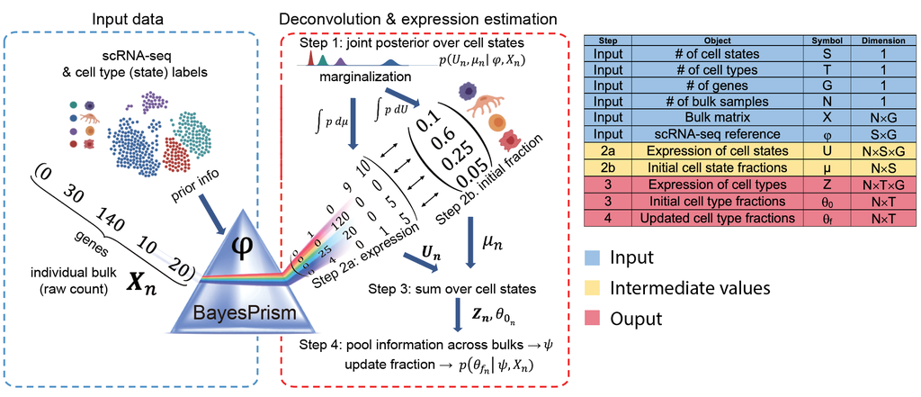

# Load the BayesPrism package

```r
suppressWarnings(library(BayesPrism))
```

# Load the dataset

The rdata file is stored at `"your_git_repository/tutorial.dat/tutorial.gbm.rdata"`

```r
load("../tutorial.dat/tutorial.gbm.rdata")
ls()
```

```
#> [1] "bk.dat"            "cell.state.labels" "cell.type.labels"  "sc.dat"
```

```r
dim(bk.dat)
```

```
#> [1]   169 60483
```

```r
head(rownames(bk.dat))
```

```
#> [1] "TCGA-06-2563-01A-01R-1849-01" "TCGA-06-0749-01A-01R-1849-01" "TCGA-06-5418-01A-01R-1849-01" "TCGA-06-0211-01B-01R-1849-01" "TCGA-19-2625-01A-01R-1850-01" "TCGA-19-4065-02A-11R-2005-01"
```

```r
head(colnames(bk.dat))
```

```
#> [1] "ENSG00000000003.13" "ENSG00000000005.5"  "ENSG00000000419.11" "ENSG00000000457.12" "ENSG00000000460.15" "ENSG00000000938.11"
```

The rdata file contains four objects required for running BayesPrism.

- `bk.dat`: The sample-by-gene raw count matrix of bulk RNA-seq expression. `rownames` are bulk sample IDs, while `colnames` are gene names/IDs.

```r
dim(bk.dat)
```

```
#> [1]   169 60483
```

```r
head(rownames(bk.dat))
```

```
#> [1] "TCGA-06-2563-01A-01R-1849-01" "TCGA-06-0749-01A-01R-1849-01" "TCGA-06-5418-01A-01R-1849-01" "TCGA-06-0211-01B-01R-1849-01" "TCGA-19-2625-01A-01R-1850-01" "TCGA-19-4065-02A-11R-2005-01"
```

```r
head(colnames(bk.dat))
```

```
#> [1] "ENSG00000000003.13" "ENSG00000000005.5"  "ENSG00000000419.11" "ENSG00000000457.12" "ENSG00000000460.15" "ENSG00000000938.11"
```

- `sc.dat`: The cell-by-gene raw count matrix of single cell RNA-seq expression. `rownames` are cell IDs, while `colnames` are gene names/IDs. `sc.dat` should be a dense matrix. If your `sc.dat` is a sparse matrix (`dgCMatrix`), you should convert it to a dense matrix, i.e., `sc.dat <- as.matrix(sc.dat)`

```r
dim(sc.dat)
```

```
#> [1] 23793 60294
```

```r
head(rownames(sc.dat))
```

```
#> [1] "PJ016.V3" "PJ016.V4" "PJ016.V5" "PJ016.V6" "PJ016.V7" "PJ016.V8"
```

```r
head(colnames(sc.dat))
```

```
#> [1] "ENSG00000130876.10" "ENSG00000134438.9"  "ENSG00000269696.1"  "ENSG00000230393.1"  "ENSG00000266744.1"  "ENSG00000202281.1"
```

- Note that BayesPrism will perform deconvolution over genes shared between the mixture and scRNA-seq reference, i.e., by intersecting colnames(mixture) and colnames(reference). Therefore, **please make sure to use consistent gene annotations** (TCGA RNA-seq uses GENCODE v22).
- **We recommend the use of unnormalized and untransformed count data.** When raw count is not available, linear normalization, such as TPM, RPM, RPKM, FPKM, is also acceptable, as BayesPrism is robust to linear multiplicative difference between the reference and mixture. Ideally, if using normalized data, it is the best to supply reference and bulk transformed by the same method. log transformation should be avoided.
- `cell.type.labels` is a character vector of the same length as `nrow(sc.dat)` to denote the cell type of each cell in the reference.

```r
sort(table(cell.type.labels))
```

```
#> cell.type.labels
#>       tcell       oligo    pericyte endothelial     myeloid       tumor
#>          67         160         489         492        2505       20080
```

- `cell.state.labels` is a character vector of the same length as `nrow(sc.dat)` to denote the cell state of each cell in the reference. In our example, cell states of malignant cells were obtained by sub-clustering the malignant cells from each patient, and cell states of myeloid cells were obtained by clustering myeloid cells from all patients. We define multiple cell states for these two cell types, as they contain substantial heterogeneity while also having sufficient number of cells for sub-clustering.

```r
sort(table(cell.state.labels))
```

```
#> cell.state.labels
#> PJ017-tumor-6 PJ032-tumor-5     myeloid_8 PJ032-tumor-4 PJ032-tumor-3 PJ017-tumor-5         tcell PJ032-tumor-2 PJ030-tumor-5     myeloid_7 PJ035-tumor-8 PJ017-tumor-4 PJ017-tumor-3 PJ017-tumor-2 PJ017-tumor-0 PJ017-tumor-1 PJ018-tumor-5     myeloid_6     myeloid_5 PJ035-tumor-7         oligo PJ0…
#>            22            41            49            57            62            64            67            72            73            75            81            83            89           101           107           107           113           130           141           150           160    …
```

```r
table(cbind.data.frame(cell.state.labels, cell.type.labels))
```

```
#>                  cell.type.labels
#> cell.state.labels endothelial myeloid oligo pericyte tcell tumor
#>     endothelial           492       0     0        0     0     0
#>     myeloid_0               0     550     0        0     0     0
#>     myeloid_1               0     526     0        0     0     0
#>     myeloid_2               0     386     0        0     0     0
#>     myeloid_3               0     382     0        0     0     0
#>     myeloid_4               0     266     0        0     0     0
#>     myeloid_5               0     141     0        0     0     0
#>     myeloid_6               0     130     0        0     0     0
#>     myeloid_7               0      75     0        0     0     0
#>     myeloid_8               0      49     0        0     0     0
#>     oligo                   0       0   160        0     0     0
#>     pericyte                0       0     0      489     0     0
#>     PJ016-tumor-0           0       0     0        0     0   621
#>     PJ016-tumor-1           0       0     0        0     0   619
#>     PJ016-tumor-2           0       0     0        0     0   481
#>     PJ016-tumor-3           0       0     0        0     0   420
#>     PJ016-tumor-4           0       0     0        0     0   375
#>     PJ016-tumor-5           0       0     0        0     0   308
#>     PJ016-tumor-6           0       0     0        0     0   261
#>     PJ017-tumor-0           0       0     0        0     0   107
#>     PJ017-tumor-1           0       0     0        0     0   107
#>     PJ017-tumor-2           0       0     0        0     0   101
#>     PJ017-tumor-3           0       0     0        0     0    89
#>     PJ017-tumor-4           0       0     0        0     0    83
#>     PJ017-tumor-5           0       0     0        0     0    64
#>     PJ017-tumor-6           0       0     0        0     0    22
#>     PJ018-tumor-0           0       0     0        0     0   444
#>     PJ018-tumor-1           0       0     0        0     0   429
#>     PJ018-tumor-2           0       0     0        0     0   403
#>     PJ018-tumor-3           0       0     0        0     0   361
#>     PJ018-tumor-4           0       0     0        0     0   262
#>     PJ018-tumor-5           0       0     0        0     0   113
#>     PJ025-tumor-0           0       0     0        0     0   971
#>     PJ025-tumor-1           0       0     0        0     0   941
#>     PJ025-tumor-2           0       0     0        0     0   630
#>     PJ025-tumor-3           0       0     0        0     0   601
#>     PJ025-tumor-4           0       0     0        0     0   523
#>     PJ025-tumor-5           0       0     0        0     0   421
```

[output cut: 20 more lines]

```
#>     PJ035-tumor-4           0       0     0        0     0   385
#>     PJ035-tumor-5           0       0     0        0     0   334
#>     PJ035-tumor-6           0       0     0        0     0   241
#>     PJ035-tumor-7           0       0     0        0     0   150
#>     PJ035-tumor-8           0       0     0        0     0    81
#>     PJ048-tumor-0           0       0     0        0     0   545
#>     PJ048-tumor-1           0       0     0        0     0   463
#>     PJ048-tumor-2           0       0     0        0     0   437
#>     PJ048-tumor-3           0       0     0        0     0   333
#>     PJ048-tumor-4           0       0     0        0     0   303
#>     PJ048-tumor-5           0       0     0        0     0   277
#>     PJ048-tumor-6           0       0     0        0     0   244
#>     PJ048-tumor-7           0       0     0        0     0   228
#>     PJ048-tumor-8           0       0     0        0     0   169
#>     tcell                   0       0     0        0    67     0
```

- **Please make sure that all cell states contain a reasonable number of cells, e.g. >20 or >50, so that their profile can be represented accurately.**
- **What to supply for cell.state.labels and cell.type.labels?** The definition of cell type and cell state can be somewhat arbitrary (similar to the issue of assigning cell types for scRNA-seq) and depends on the question of interest. Their definitions depend on the granularity we aim at and the confidence of the cell.type.labels in scRNA-seq data. Usually, a good rule of thumb is as follows. 1) Define cell types as the cluster of cells having a sufficient number of significantly differentially expressed genes than other cell types, e.g., greater than 50 or even 100. For clusters that are too similar in transcription, we recommend treating them as cell states, which will be summed up before the final Gibbs sampling. Therefore, cell states are often suitable for cells that form a continuum on the phenotypic manifold rather than distinct clusters. 2) Define multiple cell states for cell types of significant heterogeneity, such as malignant cells, and of interest to deconvolve their transcription.

# QC of cell type and state labels

We recommend first plotting the pairwise correlation matrix between cell states and between cell types. This will give us a sense of their quality. In cases where cell types/states are not represented by sufficient amount of information (low cell count and/or low library size), the low-quality cell types/states tend to cluster together. Users may re-cluster the data at higher granularity, or merge those cell types/states with the most similar cell types/states, or remove them (if re-clustering and merging is not appropriate).

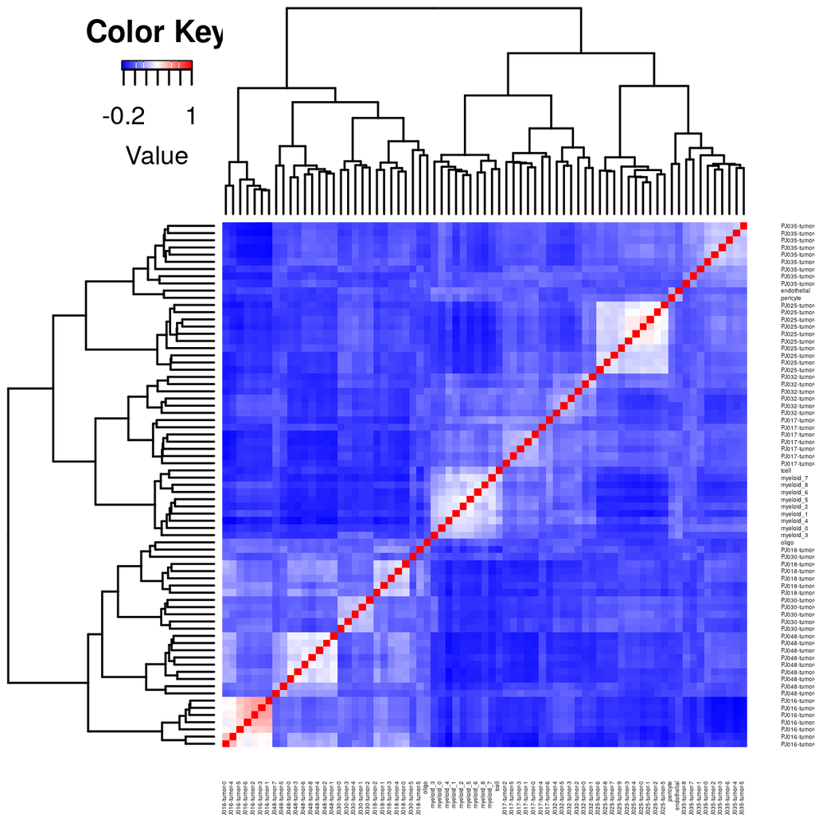

```r
plot.cor.phi (input=sc.dat,
                         input.labels=cell.state.labels,
                         title="cell state correlation",
                         #specify pdf.prefix if need to output to pdf
                         #pdf.prefix="gbm.cor.cs",
                         cexRow=0.2, cexCol=0.2,
                         margins=c(2,2))
```

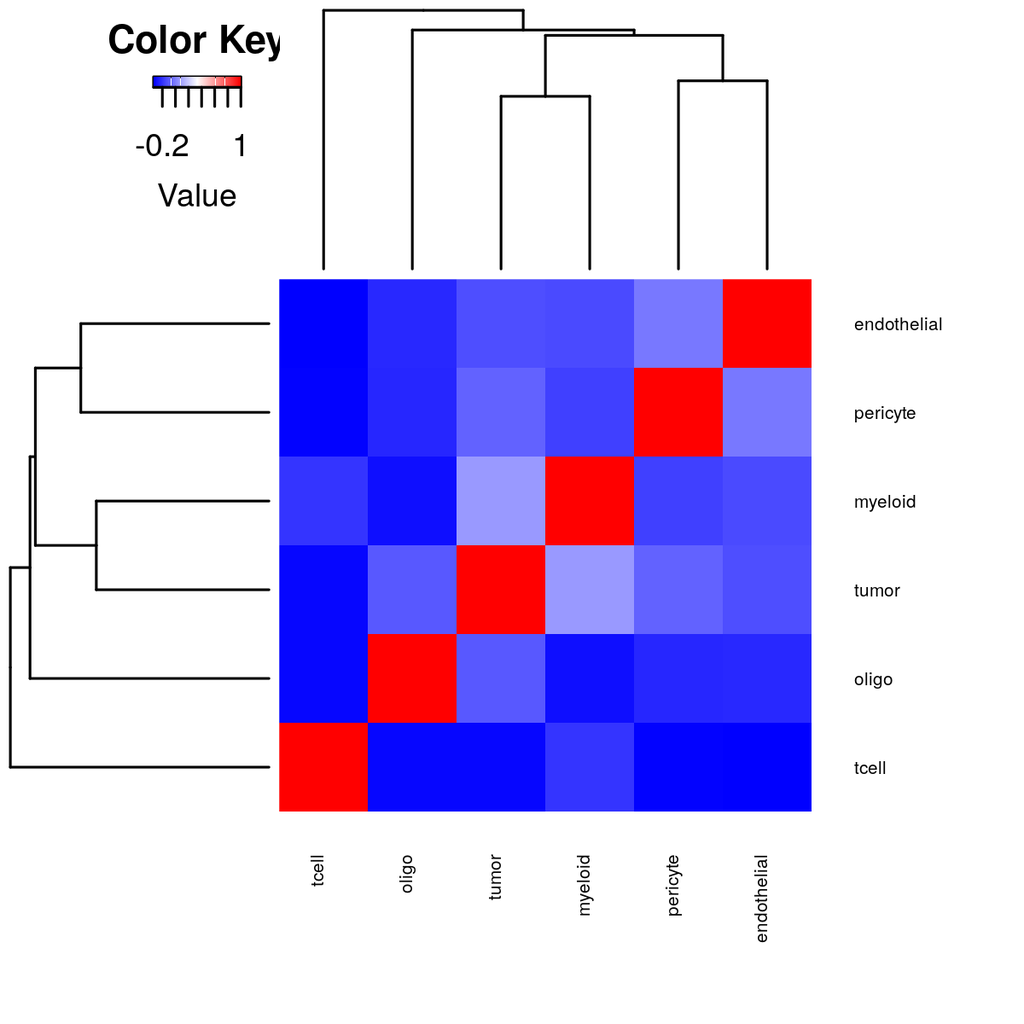

```r
plot.cor.phi (input=sc.dat,
                         input.labels=cell.type.labels,
                         title="cell type correlation",
                         #specify pdf.prefix if need to output to pdf
                         #pdf.prefix="gbm.cor.ct",
                         cexRow=0.5, cexCol=0.5,
                         )
```

# Filter outlier genes

Gene expressed at high magnitude, such as ribosomal protein genes and mitochondrial genes, may dominate the distribution and bias the inference. These genes are often not informative in distinguishing cell types and can be a source of large spurious variance. As a result, they can be detrimental to deconvolution. We recommend the removal of these genes.

- Users may visualize the distribution of outlier genes from scRNA-seq reference. We compute the mean expression and of each gene across all cell types, and their cell type specificity scores.
- Visualize and determine outlier genes from scRNA-seq data

```
#> EMSEMBLE IDs detected.
```

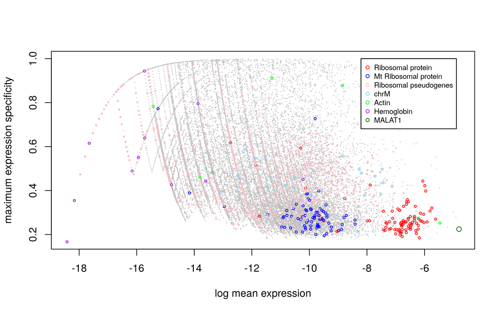

```r
sc.stat <- plot.scRNA.outlier(
  input=sc.dat, #make sure the colnames are gene symbol or ENSMEBL ID
  cell.type.labels=cell.type.labels,
  species="hs", #currently only human(hs) and mouse(mm) annotations are supported
  return.raw=TRUE #return the data used for plotting.
  #pdf.prefix="gbm.sc.stat" specify pdf.prefix if need to output to pdf
)
```

As shown by the plot, ribosomal protein genes often show high mean expression and low cell type specificity scores.

Users may also subset genes from sc.dat based on the statistics outputted by the function if needed.

```r
head(sc.stat)
```

```
#>                    exp.mean.log  max.spec other_Rb  chrM  chrX  chrY    Rb   Mrp   act    hb MALAT1
#> ENSG00000130876.10    -13.59828 0.8473029    FALSE FALSE FALSE FALSE FALSE FALSE FALSE FALSE  FALSE
#> ENSG00000134438.9     -16.08255 0.8914740    FALSE FALSE FALSE FALSE FALSE FALSE FALSE FALSE  FALSE
#> ENSG00000269696.1     -13.12002 0.7509754    FALSE FALSE FALSE FALSE FALSE FALSE FALSE FALSE  FALSE
#> ENSG00000230393.1     -13.97772 0.5654292    FALSE FALSE FALSE FALSE FALSE FALSE FALSE FALSE  FALSE
#> ENSG00000266744.1     -17.96174 0.4733715    FALSE FALSE FALSE FALSE FALSE FALSE FALSE FALSE  FALSE
#> ENSG00000202281.1     -18.42068 0.1666667    FALSE FALSE FALSE FALSE FALSE FALSE FALSE FALSE  FALSE
```

`sc.stat` shows the log of normalized mean expression (x-axis) and the maximum specificity (y-axis) of each gene, and if each gene belongs to a potential outlier category. `other_Rb` are a group of curated genes mostly consists of ribosomal pseudo-genes.

- Similarly, we may also visualize outlier genes from bulk RNA-seq. We compute the mean expression and of each gene across all cell types. As we do not have cell type level information from bulk data, we compute cell type specificity score from scRNA-seq, same as above.
- Visualize outlier genes in bulk RNA-seq

```
#> EMSEMBLE IDs detected.
```

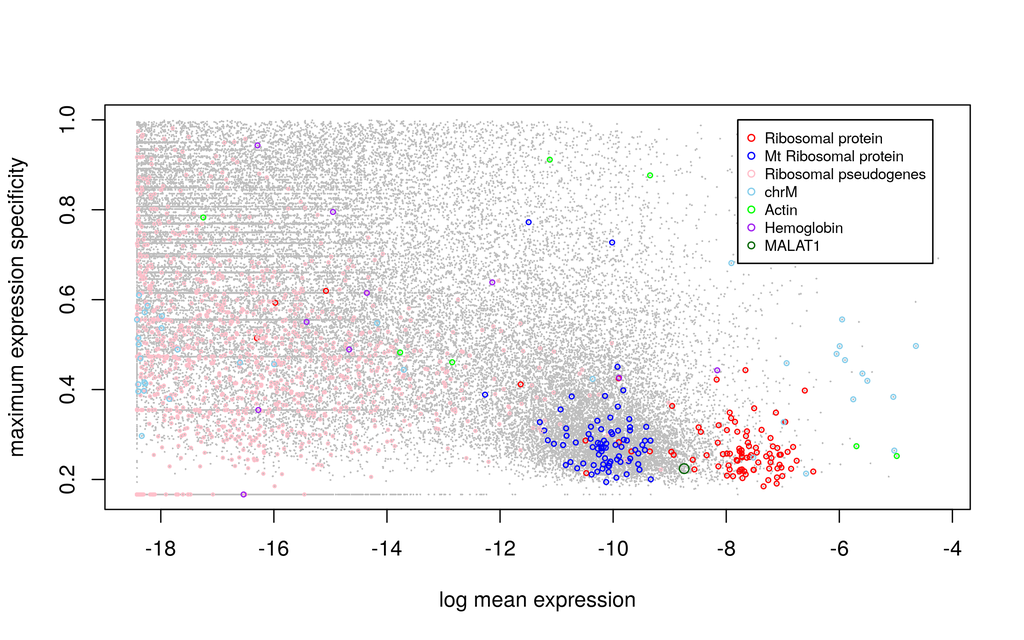

```r
bk.stat <- plot.bulk.outlier(
  bulk.input=bk.dat,#make sure the colnames are gene symbol or ENSMEBL ID
    sc.input=sc.dat, #make sure the colnames are gene symbol or ENSMEBL ID
  cell.type.labels=cell.type.labels,
  species="hs", #currently only human(hs) and mouse(mm) annotations are supported
  return.raw=TRUE
  #pdf.prefix="gbm.bk.stat" specify pdf.prefix if need to output to pdf
)
```

- check statistics from bulk RNA-seq data

```r
head(bk.stat)
```

```
#>                    exp.mean.log  max.spec other_Rb  chrM  chrX  chrY    Rb   Mrp   act    hb MALAT1
#> ENSG00000000003.13    -9.263877 0.4825322    FALSE FALSE  TRUE FALSE FALSE FALSE FALSE FALSE  FALSE
#> ENSG00000000005.5    -13.336689 0.9736083    FALSE FALSE  TRUE FALSE FALSE FALSE FALSE FALSE  FALSE
#> ENSG00000000419.11   -10.455993 0.2275788    FALSE FALSE FALSE FALSE FALSE FALSE FALSE FALSE  FALSE
#> ENSG00000000457.12   -11.298589 0.2169448    FALSE FALSE FALSE FALSE FALSE FALSE FALSE FALSE  FALSE
#> ENSG00000000460.15   -11.648474 0.2920256    FALSE FALSE FALSE FALSE FALSE FALSE FALSE FALSE  FALSE
#> ENSG00000000938.11   -11.152720 0.7347018    FALSE FALSE FALSE FALSE FALSE FALSE FALSE FALSE  FALSE
```

- Filter outlier genes from scRNA-seq data

Next, we remove the genes from selected groups. Note that when sex is not identical between the reference and mixture, we recommend excluding genes from chrX and chrY. We also remove lowly transcribed genes, as the measurement of transcription of these genes tend to be noise-prone. Removal of these genes can also speed up computation.

```r
sc.dat.filtered <- cleanup.genes (input=sc.dat,
                                  input.type="count.matrix",
                                    species="hs",
                                    gene.group=c( "Rb","Mrp","other_Rb","chrM","MALAT1","chrX","chrY") ,
                                    exp.cells=5)
```

```
#> EMSEMBLE IDs detected.
#> number of genes filtered in each category:
#>       Rb      Mrp other_Rb     chrM   MALAT1     chrX     chrY
#>       89       78     1011       37        1     2464      594
#> A total of  4214  genes from Rb Mrp other_Rb chrM MALAT1 chrX chrY  have been excluded
#> A total of  24343  gene expressed in fewer than  5  cells have been excluded
```

```r
dim(sc.dat.filtered)
```

```
#> [1] 23793 31737
```

- Next, we check the concordance of gene expression for different types of genes. As bulk and single cell data are usually collected by different experimental protocols, they may have different sensitivity to different types of genes.

```
#> EMSEMBLE IDs detected.
```

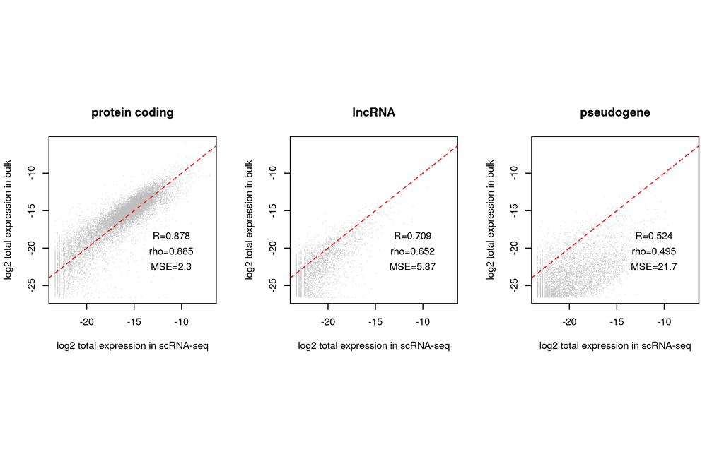

```r
#note this function only works for human data. For other species, you are advised to make plots by yourself.
plot.bulk.vs.sc (sc.input = sc.dat.filtered,
                            bulk.input = bk.dat
                            #pdf.prefix="gbm.bk.vs.sc" specify pdf.prefix if need to output to pdf
)
```

We observe that protein coding genes are the most concordant group between two assays. To reduce batch effects and speed up computation, we perform deconvolution on protein coding genes. We have also tried to run BayesPrism on all genes. The results were similar.

- Subset protein coding genes.

```r
sc.dat.filtered.pc <-  select.gene.type (sc.dat.filtered,
                                        gene.type = "protein_coding")
```

```
#> EMSEMBLE IDs detected.
#> number of genes retained in each category:
#>
#> protein_coding
#>          16148
```

- Optionally, in cases where cell types are defined in a way that some of them show very similar transcription or severe batch effects exist, e.g., reference and mixture are from very different assays (ribo-depleted RNA-seq vs poly-A tail RNA-seq or PRO-seq (nascent RNA-seq) vs RNA-seq (steady state RNA)), selecting signature genes can be beneficial. This is because the selection of signature genes can enrich for genes informative for deconvolution while reducing the impact of noise caused by technical batch effects.

We provide a function for selecting genes by performing differential expression using pair-wise t-test between cell states from different cell types. Other differential expression analysis can also be used.

```r
# Select marker genes (Optional)
# performing pair-wise t test for cell states from different cell types

diff.exp.stat <- get.exp.stat(sc.dat=sc.dat[,colSums(sc.dat>0)>3],# filter genes to reduce memory use
                                          cell.type.labels=cell.type.labels,
                                          cell.state.labels=cell.state.labels,
                                          pseudo.count=0.1, #a numeric value used for log2 transformation. =0.1 for 10x data, =10 for smart-seq. Default=0.1.
                                          cell.count.cutoff=50, # a numeric value to exclude cell state with number of cells fewer than this value for t test. Default=50.
                                          n.cores=1 #number of threads
                                          )
```

Ideally, we would like to have sufficient number of genes selected for each cell type (>50). If not, users may lower the cutoff.

To subset our count matrix over the signature genes, do

```r
sc.dat.filtered.pc.sig <- select.marker (sc.dat=sc.dat.filtered.pc,
                                                  stat=diff.exp.stat,
                                                  pval.max=0.01,
                                                  lfc.min=0.1)
```

[output not shown]

```r
dim(sc.dat.filtered.pc.sig)
```

```
#> [1] 23793  7874
```

# Construct a prism object.

A prism object contains all data required for running BayesPrism, namely, a scRNA-seq reference matrix, the cell type and cell state labels of each row of reference, and the mixture matrix for bulk RNA-seq.

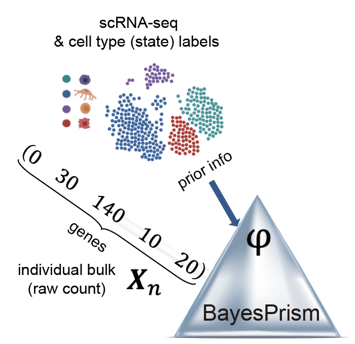

When using scRNA-seq count matrix as the input (recommended), user needs to specify `input.type = "count.matrix"`. The other option for `input.type` is `"GEP"` (gene expression profile) which is a cell state by gene matrix. This option is used when using reference derived from other assays, such as sorted bulk data.

The parameter key is a character in `cell.type.labels` that corresponds to the malignant cell type. Set to `NULL` if there are no malignant cells or the malignant cells between reference and mixture are from matched samples, in which case all cell types will be treated equally.

```r
myPrism <- new.prism(
  reference=sc.dat.filtered.pc,
  mixture=bk.dat,
  input.type="count.matrix",
  cell.type.labels = cell.type.labels,
  cell.state.labels = cell.state.labels,
  key="tumor",
  outlier.cut=0.01,
    outlier.fraction=0.1,
)
```

```
#> number of cells in each cell state
#> cell.state.labels
#> PJ017-tumor-6 PJ032-tumor-5     myeloid_8 PJ032-tumor-4 PJ032-tumor-3 PJ017-tumor-5         tcell PJ032-tumor-2 PJ030-tumor-5     myeloid_7 PJ035-tumor-8 PJ017-tumor-4 PJ017-tumor-3 PJ017-tumor-2 PJ017-tumor-0 PJ017-tumor-1 PJ018-tumor-5     myeloid_6     myeloid_5 PJ035-tumor-7         oligo PJ0…
#>            22            41            49            57            62            64            67            72            73            75            81            83            89           101           107           107           113           130           141           150           160    …
#> Number of outlier genes filtered from mixture = 6
#> Aligning reference and mixture...
#> Nornalizing reference...
```

```r
#Note that outlier.cut and outlier.fraction=0.1 filter genes in X whose expression fraction is greater than outlier.cut (Default=0.01) in more than outlier.fraction (Default=0.1) of bulk data.
#Typically for dataset with reasonable quality control, very few genes will be filtered.
#Removal of outlier genes will ensure that the inference will not be dominated by outliers, which sometimes may be resulted from poor QC in mapping.
```

# Run BayesPrism.

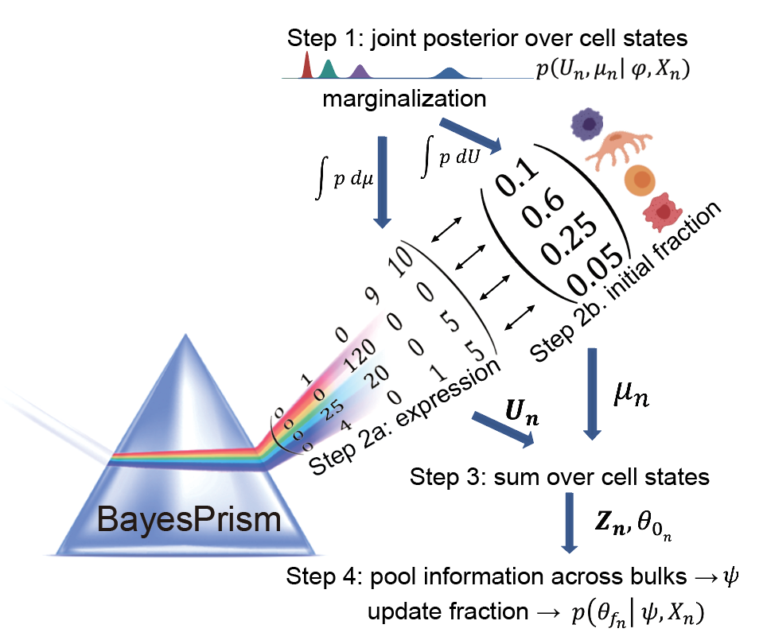

Next, we start the run of BayesPrism.

Parameters to control Gibbs sampling and optimization can be specified using `gibbs.control` and `opt.control`. Do `?run.prism` for details. We recommend the use of default parameters.

```r
bp.res <- run.prism(prism = myPrism, n.cores=50)
```

[output not shown]

Report the summary statistics.

```r
bp.res
```

```
#> Input prism info:
#> Cell states in each cell type:
#> $tumor
#>  [1] "PJ016-tumor-0" "PJ016-tumor-3" "PJ016-tumor-2" "PJ016-tumor-6" "PJ016-tumor-4" "PJ016-tumor-1" "PJ016-tumor-5" "PJ017-tumor-3" "PJ017-tumor-2" "PJ017-tumor-1" "PJ017-tumor-0" "PJ017-tumor-4" "PJ017-tumor-5" "PJ017-tumor-6" "PJ018-tumor-4" "PJ018-tumor-2" "PJ018-tumor-3" "PJ018-tumor-1" "PJ0…
#>
#> $myeloid
#> [1] "myeloid_2" "myeloid_5" "myeloid_3" "myeloid_7" "myeloid_0" "myeloid_6" "myeloid_4" "myeloid_1" "myeloid_8"
#>
#> $pericyte
#> [1] "pericyte"
#>
#> $endothelial
#> [1] "endothelial"
#>
#> $tcell
#> [1] "tcell"
#>
#> $oligo
#> [1] "oligo"
#>
#>
#> Identifier of the malignant cell type:  tumor
#> Number of cell states:  73
#> Number of cell types:  6
#> Number of mixtures:  169
#> Number of genes:  16145
#>
#> Initial cell type fractions:
#>         tumor myeloid pericyte endothelial tcell oligo
#> Min.    0.199   0.004    0.000       0.015  0.00 0.000
#> 1st Qu. 0.702   0.051    0.014       0.036  0.00 0.010
#> Median  0.775   0.102    0.025       0.046  0.00 0.025
#> Mean    0.758   0.109    0.043       0.048  0.00 0.041
#> 3rd Qu. 0.848   0.145    0.048       0.060  0.00 0.050
#> Max.    0.952   0.578    0.503       0.133  0.01 0.329
#> Updated cell type fractions:
#>         tumor myeloid pericyte endothelial tcell oligo
#> Min.    0.272   0.000    0.000       0.008 0.000 0.000
#> 1st Qu. 0.751   0.046    0.006       0.027 0.000 0.002
#> Median  0.815   0.090    0.014       0.039 0.000 0.011
#> Mean    0.801   0.098    0.030       0.041 0.001 0.029
#> 3rd Qu. 0.878   0.130    0.033       0.053 0.001 0.036
#> Max.    0.968   0.565    0.385       0.134 0.010 0.307
```

Alternatively, if user would like to run step 4 separately from 1-3, one may do the following:

```r
# not run
bp.res.initial <- run.prism(prism = myPrism, n.cores=50, update.gibbs=FALSE)

bp.res.update <- update.theta (bp = bp.res.initial)
```

# Extract results

- Understand the results BayesPrism is expected to generate the following results:

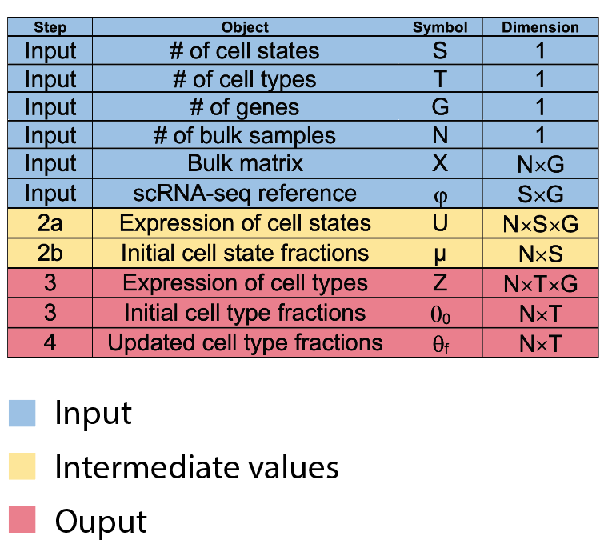

The output from `bp.res` is an S4 object of the class `"BayesPrism"`. Let’s take a look at what’s inside:

```r
slotNames(bp.res)
```

```
#> [1] "prism"                       "posterior.initial.cellState" "posterior.initial.cellType"  "reference.update"            "posterior.theta_f"           "control_param"
```

- `"prism"` is the input prism.
- `"posterior.initial.cellState"` is the result of step 2.
- `"posterior.initial.cellType"` is the result of step 3.
- `"reference.update"` is the updated reference $\psi$.
- `"posterior.theta_f"` is the result of step 4.
- `"control_param"` contains the parameters to run BayesPrism.

We provide utility functions to extract deconvolved cell type fraction and expression from the output of `run.prism`.

```r
# extract posterior mean of cell type fraction theta
theta <- get.fraction (bp=bp.res,
            which.theta="final",
            state.or.type="type")

head(theta)
```

```
#>                                  tumor    myeloid     pericyte endothelial        tcell        oligo
#> TCGA-06-2563-01A-01R-1849-01 0.8392297 0.04329259 2.999022e-02  0.07528272 6.474488e-04 0.0115573149
#> TCGA-06-0749-01A-01R-1849-01 0.7090654 0.17001073 8.995526e-07  0.01275526 1.179331e-06 0.1081665709
#> TCGA-06-5418-01A-01R-1849-01 0.8625322 0.09839143 9.729268e-03  0.02416954 7.039913e-07 0.0051768589
#> TCGA-06-0211-01B-01R-1849-01 0.8893449 0.04482991 1.131622e-02  0.05435490 2.508238e-06 0.0001515524
#> TCGA-19-2625-01A-01R-1850-01 0.9406438 0.03546026 1.932740e-03  0.01309753 4.535897e-06 0.0088610997
#> TCGA-19-4065-02A-11R-2005-01 0.6763166 0.08374439 1.849921e-01  0.01918132 3.541126e-04 0.0354114398
```

```r
# extract coefficient of variation (CV) of cell type fraction
theta.cv <- bp.res@posterior.theta_f@theta.cv

head(theta.cv)
```

```
#>                                     tumor      myeloid     pericyte endothelial      tcell       oligo
#> TCGA-06-2563-01A-01R-1849-01 0.0001722829 0.0016025331 0.0026568433 0.001853843 0.05452368 0.005606057
#> TCGA-06-0749-01A-01R-1849-01 0.0002333853 0.0006859332 0.8109050326 0.005683516 0.74729658 0.001276784
#> TCGA-06-5418-01A-01R-1849-01 0.0001601128 0.0009389782 0.0070872942 0.004131925 0.83670176 0.011362855
#> TCGA-06-0211-01B-01R-1849-01 0.0001175529 0.0014412303 0.0055064706 0.001673105 0.60905434 0.280609474
#> TCGA-19-2625-01A-01R-1850-01 0.0001327408 0.0023661566 0.0335184780 0.006286823 0.73453327 0.006138184
#> TCGA-19-4065-02A-11R-2005-01 0.0002862600 0.0012227981 0.0009100677 0.005660069 0.06371147 0.002243368
```

- theta.cv quantifies how concentrated the posterior distribution is. Higher theta value is associated with lower CV. When performing rank-ordered statistics, such as Spearman’s rank correlation, users may mask theta (e.g. clip at zero for small theta) where the CV is above some number, say > 0.1. Lower sequencing depth, which is the case for spatial transcriptomics, is generally associated with higher CV. A reasonable cutoff of CV for deconvolving Visium data may be ~0.5.

```r
# extract posterior mean of cell type-specific gene expression count matrix Z
Z.tumor <- get.exp (bp=bp.res,
                          state.or.type="type",
                          cell.name="tumor")

head(t(Z.tumor[1:5,]))
```

```
#>                    TCGA-06-2563-01A-01R-1849-01 TCGA-06-0749-01A-01R-1849-01 TCGA-06-5418-01A-01R-1849-01 TCGA-06-0211-01B-01R-1849-01 TCGA-19-2625-01A-01R-1850-01
#> ENSG00000130876.10                       55.980                      444.980                        9.000                       56.996                       15.996
#> ENSG00000165244.6                       206.344                       38.096                      291.872                      530.732                      507.788
#> ENSG00000173597.7                        17.100                        6.588                       21.804                       28.744                       10.800
#> ENSG00000158022.6                         0.000                        0.476                        2.616                        0.960                        7.824
#> ENSG00000167220.10                     2273.824                     1060.976                     2775.180                     2368.016                     2084.620
#> ENSG00000126106.12                      678.468                      685.948                      481.000                      698.888                     1296.080
```

```r
#save the result
save(bp.res, file="bp.res.rdata")
```

# Downstream analysis

Potential downstream analysis can be performed using theta and Z are:

- Clustering bulk samples by theta or Z (Z can be normalized by `vst(round(t(Z.tumor))`), using the `vst` function from the `DESeq2` package.)
- Computing z-scores of signature genes for Z of the cell type of interest.
- Survival analysis and correlation with other clinical covariates using theta and Z.
- Correlating Z (after normalization using vst or from `bp.res@reference.update@psi_mal`) with theta to understand how gene expression of each gene (in malignant cells) correlates with the cell type fraction of non-malignant cells in tumor micro-environment, followed by gene set enrichment analysis (as done in BayesPrism paper).
- Embedding learning of malignant gene expression (see “Tutorial: embedding learning of malignant cell expression using BayesPrism”)